# Solução Airbnb Rio

### minimum_nights

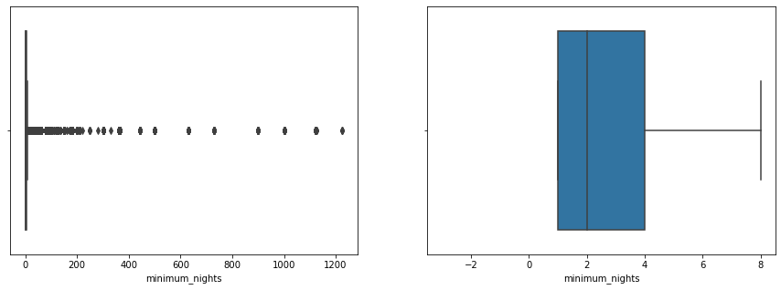

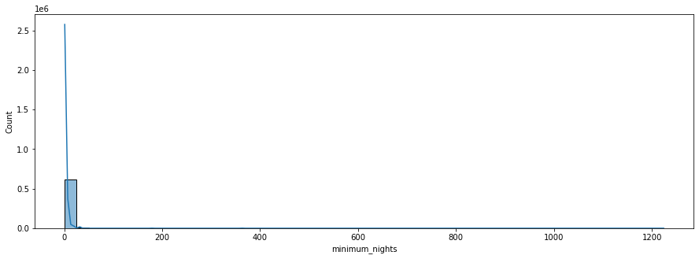

```python
diagrama_cx(base_d_dados.minimum_nights)
histrograma(base_d_dados.minimum_nights)
```

```python
# Excluindo outliers do minimum_nights
base_d_dados, linhas_removida = excluir_outliers(base_d_dados, "minimum_nights")
print('{} linhas removidas'.format(linhas_removida))
```

```
40383 linhas removidas
```

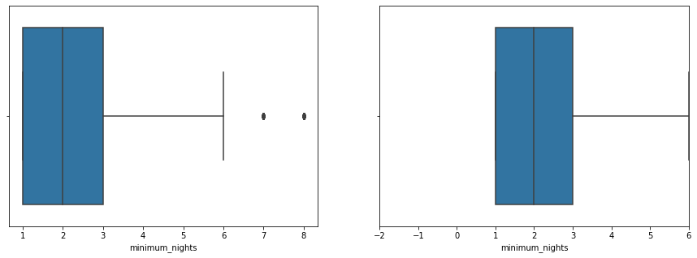

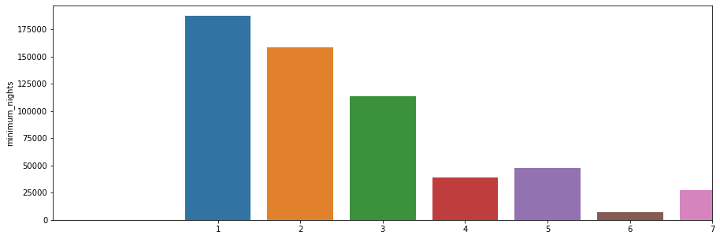

```python
# visualizar graficos
diagrama_cx(base_d_dados.minimum_nights)
grafico_barra(base_d_dados.minimum_nights)
```

### maximum_nights

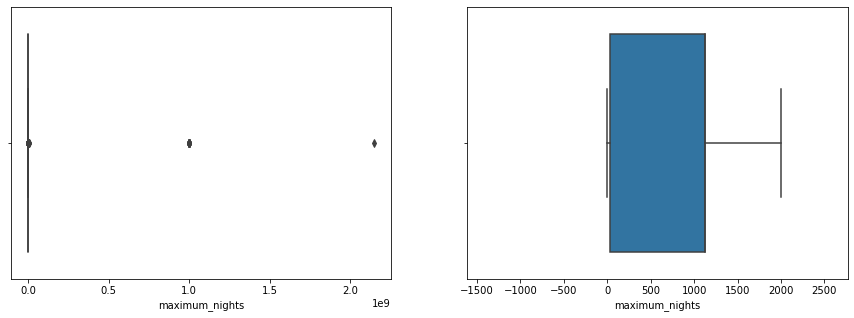

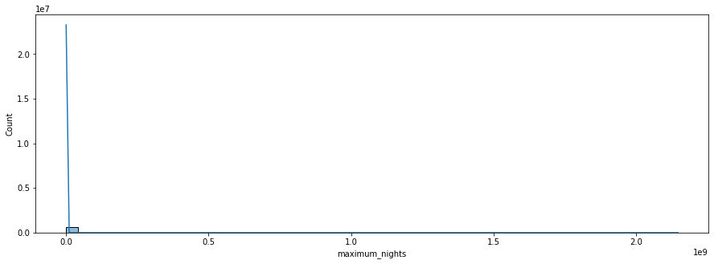

```python
diagrama_cx(base_d_dados.maximum_nights)
histrograma(base_d_dados.maximum_nights)
```

Essa coluna de maximum_nights também irar afetar nossa analise levando em consideração que não vamos ter um limite maximo de noite e que normamente este campo não é preenchido

```python
# excluindo coluna
base_d_dados = base_d_dados.drop('maximum_nights', axis=1)
base_d_dados.shape
```

```
(581983, 21)
```

### number_of_reviews

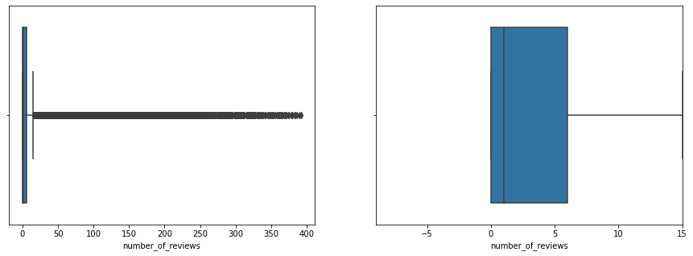

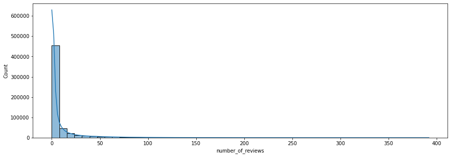

```python
diagrama_cx(base_d_dados.number_of_reviews)
histrograma(base_d_dados.number_of_reviews)
```

Se excluirmos os outliers, vamos excluir as pessoas que tem a maior quantidade de reviews (o que normalmente são os hosts que têm mais aluguel). Isso pode impactar muito negativamente o nosso modelo Pensando no nosso objetivo, se eu tenho um imóvel parado e quero colocar meu imóvel lá, é claro que eu não tenho review nenhuma. Então talvez tirar essa característica da análise pode na verdade acabar ajudando.

```python
# excluindo coluna
base_d_dados = base_d_dados.drop('number_of_reviews', axis=1)
base_d_dados.shape
```

```
(581983, 20)
```

### Tratamento de Colunas de Valores de Texto

```
Apartment                 458354
House                      51387
Condominium                26456
Serviced apartment         12671
Loft                       12352
Guest suite                 3621
Bed and breakfast           3472
Hostel                      2665
Guesthouse                  2155
Other                       1957
Villa                       1294
Townhouse                    969
Aparthotel                   693
Chalet                       481
Earth house                  468
Tiny house                   457
Boutique hotel               447
Hotel                        376
Casa particular (Cuba)       298
Cottage                      230
Bungalow                     207
Dorm                         185
Cabin                        141
Nature lodge                 124
Castle                        80
Treehouse                     76
Island                        54
Boat                          53
Hut                           40
Campsite                      34
Resort                        31
Camper/RV                     24
Yurt                          23
Tent                          18
Tipi                          17
Barn                          15
Farm stay                     13
Pension (South Korea)          9
Dome house                     8
Igloo                          6
In-law                         6
Vacation home                  4
Houseboat                      3
Timeshare                      3
Pousada                        3
Casa particular                2
Plane                          1
Name: property_type, dtype: int64
```

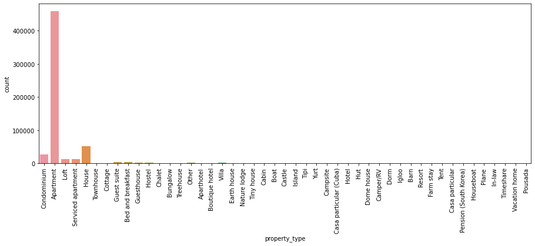

```python
print(base_d_dados.property_type.value_counts())

plt.figure(figsize=(15, 5))
grafico = sns.countplot('property_type', data=base_d_dados)
grafico.tick_params(axis='x', rotation=90)
```

todos os tipos de propriedade que têm menos de 2.000 propriedades na base de dados, eu vou agrupar em um grupo chamado "outros"

```python
# Agrupando todos os tipo de imoveis que tem menos de 2000
tabela_casa = base_d_dados.property_type.value_counts()
colunas_agrupar = []

for tipo in tabela_casa.index:
    if tabela_casa[tipo] < 2000:
        colunas_agrupar.append(tipo)
print(colunas_agrupar)
for tipo in colunas_agrupar:
    base_d_dados.loc[base_d_dados["property_type"]==tipo, "property_type"] = "outros"
```

[output not shown]

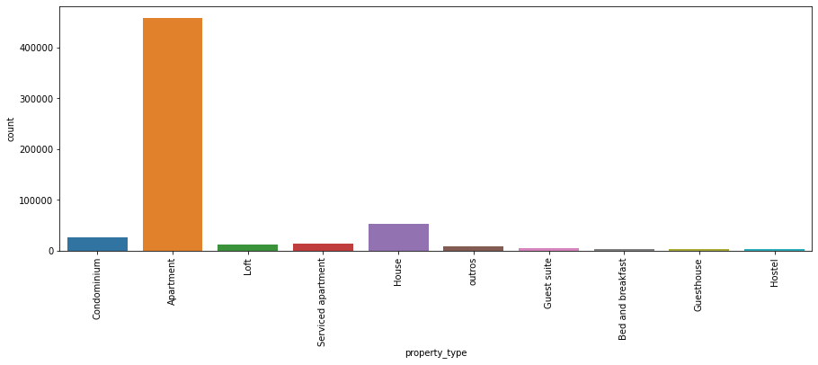

```python
plt.figure(figsize=(15, 5))
grafico = sns.countplot('property_type', data=base_d_dados)
grafico.tick_params(axis='x', rotation=90)
```

### room_type

```
Entire home/apt    372443
Private room       196859
Shared room         11714
Hotel room            967
Name: room_type, dtype: int64
```

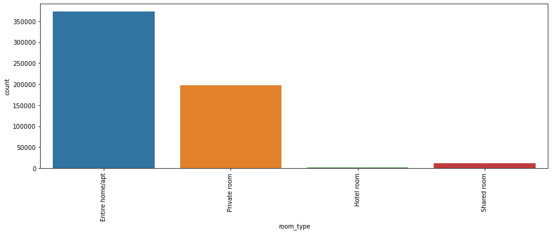

```python
print(base_d_dados.room_type.value_counts())

plt.figure(figsize=(15, 5))
grafico = sns.countplot('room_type', data=base_d_dados)
grafico.tick_params(axis='x', rotation=90)
```

### bed_type

```
Real Bed         570643
Pull-out Sofa      8055
Futon              1634
Airbed             1155
Couch               496
Name: bed_type, dtype: int64
------------------------------------------------------------
['Pull-out Sofa', 'Futon', 'Airbed', 'Couch']
Real Bed         888046
Pull-out Sofa      9607
Futon              2213
Airbed             1647
Couch               697
Name: bed_type, dtype: int64
```

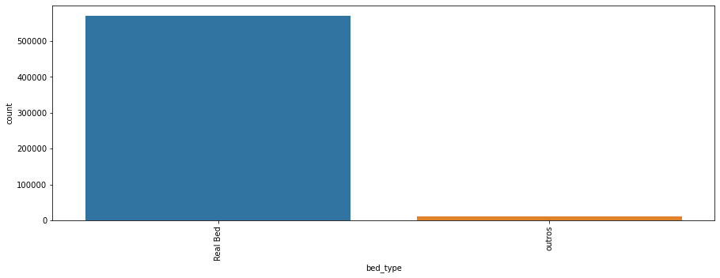

```python
print(base_d_dados['bed_type'].value_counts())

# agrupando categorias de cancellation_pollicy
tabela_bed = base_d_dados['bed_type'].value_counts()
colunas_agrupar = []

for tipo in tabela_bed.index:
    if tabela_bed[tipo] < 10000:
        colunas_agrupar.append(tipo)
print("-"*60)
print(colunas_agrupar)

for tipo in colunas_agrupar:
    base_d_dados.loc[base_d_dados['bed_type']==tipo, 'bed_type'] = 'outros'

print(base_airbnb['bed_type'].value_counts())
plt.figure(figsize=(15, 5))
grafico = sns.countplot('bed_type', data=base_d_dados)
grafico.tick_params(axis='x', rotation=90)
```

### cancellation_policy

```
flexible                       258096
strict_14_with_grace_period    200743
moderate                       113281
strict                           9696
super_strict_60                   135
super_strict_30                    32
Name: cancellation_policy, dtype: int64
------------------------------------------------------------
['strict', 'super_strict_60', 'super_strict_30']
flexible                       386758
strict_14_with_grace_period    338301
moderate                       149753
strict                          16243
super_strict_60                  8202
super_strict_30                  2953
Name: cancellation_policy, dtype: int64
```

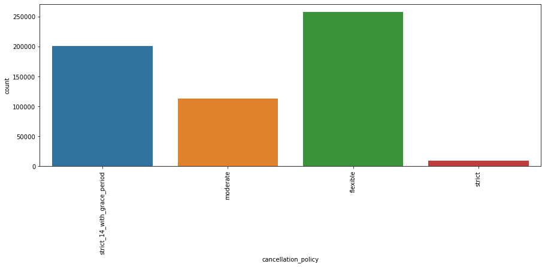

```python
print(base_d_dados['cancellation_policy'].value_counts())

# agrupando categorias de cancellation_pollicy
tabela_cancellation = base_d_dados['cancellation_policy'].value_counts()
colunas_agrupar = []

for tipo in tabela_cancellation.index:
    if tabela_cancellation[tipo] < 10000:
        colunas_agrupar.append(tipo)
print("-"*60)
print(colunas_agrupar)

for tipo in colunas_agrupar:
    base_d_dados.loc[base_d_dados['cancellation_policy']==tipo, 'cancellation_policy'] = 'strict'

print(base_airbnb['cancellation_policy'].value_counts())
plt.figure(figsize=(15, 5))
grafico = sns.countplot('cancellation_policy', data=base_d_dados)
grafico.tick_params(axis='x', rotation=90)
```

### - amenities

Como temos uma diversidade muito grande de amenities e, às vezes, as mesmas amenities podem ser escritas de forma diferente, vamos avaliar a quantidade de amenities como o parâmetro para o nosso modelo.

```python
print(base_d_dados['amenities'].iloc[1].split(','))
print(len(base_d_dados['amenities'].iloc[1].split(',')))

base_d_dados['n_amenities'] = base_d_dados['amenities'].str.split(',').apply(len)
```

```
['{TV', '"Cable TV"', 'Internet', 'Wifi', '"Air conditioning"', 'Kitchen', 'Doorman', 'Elevator', '"Buzzer/wireless intercom"', '"Family/kid friendly"', 'Hangers', '"Hair dryer"', 'Iron', '"Laptop friendly workspace"}']
14
```

```python
base_d_dados = base_d_dados.drop('amenities', axis=1)
base_d_dados.shape
```

```
(581983, 20)
```

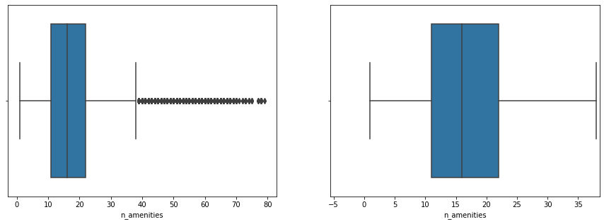

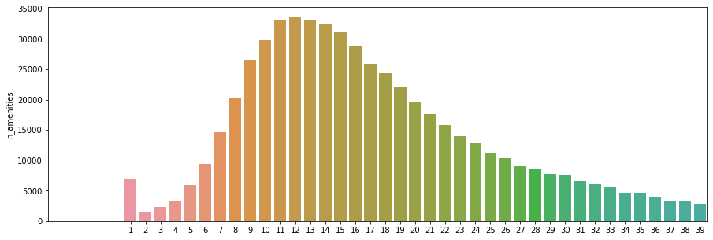

```python
# visualizar grafico
diagrama_cx(base_d_dados['n_amenities'])
grafico_barra(base_d_dados['n_amenities'])
```

```python
base_d_dados.n_amenities.value_counts()
# agora a coluna de amenities virou coluna com valor numerico, agora da pra excluir os outliers
```

```
12    33569
13    33012
11    32982
14    32473
15    31153
      ...
75        6
77        5
72        5
79        2
71        2
Name: n_amenities, Length: 78, dtype: int64
```

```python
# excluir outliers
base_d_dados, linhas_removidas = excluir_outliers(base_d_dados, 'n_amenities')
print('{} linhas removidas'.format(linhas_removidas))
```

```
24343 linhas removidas
```

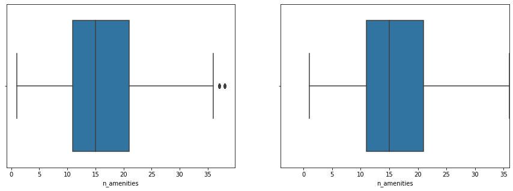

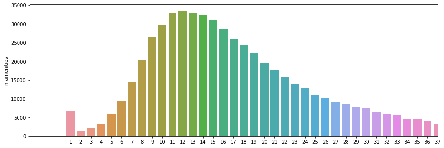

```python
# visualizar grafico apos excluir outliers
diagrama_cx(base_d_dados['n_amenities'])
grafico_barra(base_d_dados['n_amenities'])
```

### Visualização de Mapa das Propriedades

Vamos criar um mapa que exibe um pedaço da nossa base de dados aleatório (50.000 propriedades) para ver como as propriedades estão distribuídas pela cidade e também identificar os locais de maior preço

```python
amostra = base_d_dados.sample(n=50000)
centro_mapa = {'lat':amostra.latitude.mean(), 'lon':amostra.longitude.mean()}
mapa = px.density_mapbox(amostra, lat='latitude', lon='longitude',z='price', radius=2.5,
                        center=centro_mapa, zoom=10,
                        mapbox_style='stamen-terrain')
mapa.show()
```

[interactive chart not shown]

### Encoding

Ajustar as features para facilitar o trabalho do modelo futuro (features de categoria, true e false, etc.)

```python
# Features de Valores True ou False, vamos substituir True por 1 e False por 0.

colunas_tf = ['host_is_superhost', 'instant_bookable', 'is_business_travel_ready']
base_d_dados_cod = base_d_dados.copy()
for coluna in colunas_tf:
    base_d_dados_cod.loc[base_d_dados_cod[coluna]=='t', coluna] = 1
    base_d_dados_cod.loc[base_d_dados_cod[coluna]=='f', coluna] = 0
```

Features de Categoria (features em que os valores da coluna são textos) vamos utilizar o método de encoding de variáveis dummies

```python
colunas_categorias = ['property_type', 'room_type', 'bed_type', 'cancellation_policy']
base_d_dados_cod = pd.get_dummies(data=base_d_dados_cod, columns=colunas_categorias)
display(base_d_dados_cod.head())
```

|  | host_is_superhost | host_listings_count | latitude | longitude | accommodates | bathrooms | bedrooms | beds | price | extra_people | ... | room_type_Entire home/apt | room_type_Hotel room | room_type_Private room | room_type_Shared room | bed_type_Real Bed | bed_type_outros | cancellation_policy_flexible | cancellation_policy_moderate | cancellation_policy_strict | cancellation_policy_strict_14_with_grace_period |
| --- | --- | --- | --- | --- | --- | --- | --- | --- | --- | --- | --- | --- | --- | --- | --- | --- | --- | --- | --- | --- | --- |
| 0 | 1 | 2.0 | -22.96592 | -43.17896 | 5 | 1.0 | 2.0 | 2.0 | 329.0 | 62.0 | ... | 1 | 0 | 0 | 0 | 1 | 0 | 0 | 0 | 0 | 1 |
| 1 | 0 | 3.0 | -22.97712 | -43.19045 | 3 | 1.0 | 1.0 | 2.0 | 158.0 | 45.0 | ... | 1 | 0 | 0 | 0 | 1 | 0 | 0 | 0 | 0 | 1 |
| 2 | 1 | 1.0 | -22.98302 | -43.21427 | 3 | 1.0 | 1.0 | 2.0 | 270.0 | 42.0 | ... | 1 | 0 | 0 | 0 | 1 | 0 | 0 | 0 | 0 | 1 |
| 3 | 1 | 1.0 | -22.98816 | -43.19359 | 3 | 1.5 | 1.0 | 2.0 | 374.0 | 62.0 | ... | 1 | 0 | 0 | 0 | 1 | 0 | 0 | 0 | 0 | 1 |
| 16 | 0 | 2.0 | -22.92873 | -43.17473 | 4 | 2.0 | 3.0 | 4.0 | 258.0 | 0.0 | ... | 1 | 0 | 0 | 0 | 1 | 0 | 0 | 0 | 0 | 1 |

5 rows × 36 columns

### Modelo de Previsão

Métricas de Avaliação Vamos usar aqui o R² que vai nos dizer o quão bem o nosso modelo consegue explicar o preço. Isso seria um ótimo parâmetro para ver o quão bom é nosso modelo -> Quanto mais próximo de 100%, melhor

RSME: Vou calcular também o Erro Quadrático Médio, que vai mostrar para gente o quanto o nosso modelo está errando. -> Quanto menor for o erro, melhor

```python
# definfir função para avalisar o modelo / quanto maus proximo de 100% melhor
def avaliar_modelo(nome_modelo, y_teste, previsao):
    r2 = r2_score(y_teste, previsao)
    RSME = np.sqrt(mean_squared_error(y_teste, previsao))
    return f'Modelo {nome_modelo}:\nR²:{r2:.2%}\nRSME:{RSME:.2f}'
```

Escolha dos Modelos a Serem Testados

RandomForest

LinearRegression

Extra Tree

Estamos querendo calcular o preço, portanto, queremos prever um valor numérico.

Mas na dúvida, esses 3 modelos que usamos aqui são bem bons para muitos problemas de Regressão.

```python
modelo_rf = RandomForestRegressor()
modelo_lr = LinearRegression()
modelo_et = ExtraTreesRegressor()

modelos = {'RandomForest': modelo_rf,
          'LinearRegression': modelo_lr,
          'ExtraTrees': modelo_et,
          }

y = base_d_dados_cod['price']
X = base_d_dados_cod.drop('price', axis=1)
```

```python
# Separa os dados em treino e teste + Treino do Modelo
X_train, X_test, y_train, y_test = train_test_split(X, y, random_state=10)

for nome_modelo, modelo in modelos.items():
    #treinar
    modelo.fit(X_train, y_train)
    #testar
    previsao = modelo.predict(X_test)
    print(avaliar_modelo(nome_modelo, y_test, previsao))
```

```
Modelo RandomForest:
R²:97.19%
RSME:44.55
Modelo LinearRegression:
R²:32.67%
RSME:217.90
Modelo ExtraTrees:
R²:97.38%
RSME:42.95
```

### Análise do Melhor Modelo

# O melhor modelo definido foi o modelo ExtraTrees

### Ajustes e Melhorias no Melhor Modelo

analise das colunas mais importantes usando no modelo, como por exempo a coluna is_business_travel_ready não é importante, tanto que não é utilizado no modelo, as colunas bedrooms,latitude e longitude são as mais importes pelo fato de estar ligado com a localização e quantas pessoas hospeda.

```python
importancia_freatures = pd.DataFrame(modelo_et.feature_importances_, X_train.columns)
importancia_freatures = importancia_freatures.sort_values(by=0, ascending=False)
display(importancia_freatures)
```

|  | 0 |
| --- | --- |
| bedrooms | 0.114376 |
| latitude | 0.104465 |
| longitude | 0.101078 |
| n_amenities | 0.089034 |
| extra_people | 0.086495 |
| accommodates | 0.074931 |
| bathrooms | 0.069895 |
| minimum_nights | 0.064794 |
| room_type_Entire home/apt | 0.063311 |
| beds | 0.052581 |
| host_listings_count | 0.039814 |
| instant_bookable | 0.021769 |
| cancellation_policy_flexible | 0.019754 |
| host_is_superhost | 0.013321 |
| property_type_Apartment | 0.012628 |
| cancellation_policy_moderate | 0.012233 |
| ano | 0.011313 |
| cancellation_policy_strict_14_with_grace_period | 0.007558 |
| property_type_House | 0.007189 |
| property_type_Condominium | 0.005380 |
| room_type_Private room | 0.004774 |
| mes | 0.004622 |
| bed_type_Real Bed | 0.002717 |
| bed_type_outros | 0.002550 |
| property_type_outros | 0.002302 |
| property_type_Serviced apartment | 0.002275 |
| property_type_Loft | 0.002238 |
| room_type_Shared room | 0.001832 |
| property_type_Bed and breakfast | 0.001390 |
| property_type_Guesthouse | 0.000873 |
| cancellation_policy_strict | 0.000848 |
| property_type_Guest suite | 0.000678 |
| property_type_Hostel | 0.000662 |
| room_type_Hotel room | 0.000322 |
| is_business_travel_ready | 0.000000 |

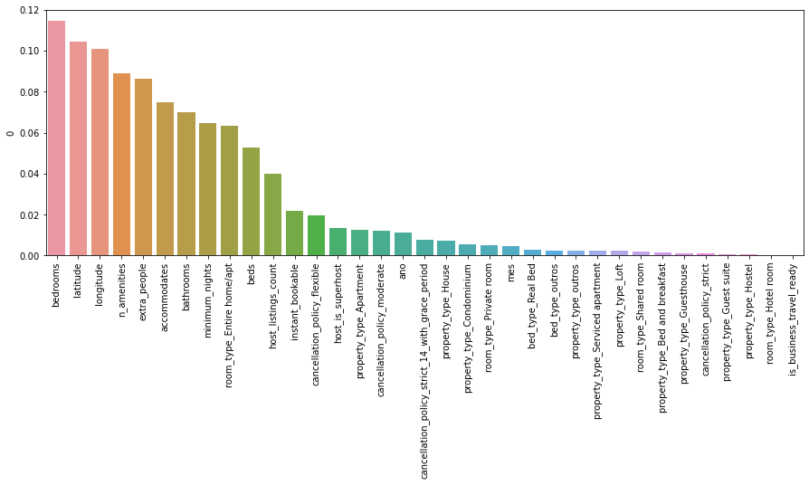

```python
plt.figure(figsize=(15, 5))
ax = sns.barplot(x=importancia_freatures.index, y=importancia_freatures[0])
ax.tick_params(axis="x", rotation=90)
```

ultimo resultado: Modelo ExtraTrees: R²:97.38% RSME:42.95, agora remover colunas irrelevantes para deixar o modelo mais rapido e tentar deixar mais preciso

```python
base_d_dados_cod = base_d_dados_cod.drop("is_business_travel_ready", axis=1)

y = base_d_dados_cod['price']
X = base_d_dados_cod.drop('price', axis=1)

# Separa os dados em treino e teste + Treino do Modelo
X_train, X_test, y_train, y_test = train_test_split(X, y, random_state=10)

modelo_et.fit(X_train, y_train)
previsao = modelo.predict(X_test)
print(avaliar_modelo(nome_modelo, y_test, previsao))
```

```
Modelo ExtraTrees:
R²:97.38%
RSME:42.95
```

resultado apos remover a coluna is_business_travel_ready: Modelo ExtraTrees: R²:97.38% RSME:42.95, não mudou porem como cotém uma coluna a menos deixa o modelo mais rapido

## Deploy do projeto

Salvar o modelo treinandoDisponibilizar o projeto para usuarios, criando arquivo joblib para ser usado para fazer previsões

```python
# Salvar base de dados tratada
X["price"] = y
X.to_csv("dados.csv")
```

```python
# exportar modelo de previsão
import joblib
joblib.dump(modelo_et, "modelo.joblib")
```

```
['modelo.joblib']
```